# Independent Review: Air Quality, Infertility and Diabetes Data

Software for Data Analysis, Lab 01: Self-directed practice

Marcos Cunchillos Just

2026-10-29

# Overview

Self-directed review of the Lab 01 skills (data import/export, missing values, recoding, contingency tables, descriptive statistics, graphics, normality and correlation) on three public datasets that were not used in the graded work:

| Dataset | Source | Design | Question |
| --- | --- | --- | --- |
| `airquality` | `datasets` | 153 daily measurements, New York, May-Sep 1973 | How are missing values distributed, and how do they bias an analysis? |
| `infert` | `datasets` | Case-control study of secondary infertility (248 women) | Is a history of induced abortions associated with infertility? |
| `Pima.tr` | `MASS` | 200 women of Pima Indian heritage assessed for diabetes | Which clinical variables differ between women with and without diabetes? |

```r
library(MASS)
library(readr)
library(dplyr)
library(ggplot2)
```

# Part 1. Data import, export and management

## 1.1 Loading `airquality`

```r
air_quality <- airquality

head(air_quality, 8)
```

|  | Ozone | Solar.R | Wind | Temp | Month | Day |
| --- | --- | --- | --- | --- | --- | --- |
| 1 | 41 | 190 | 7.4 | 67 | 5 | 1 |
| 2 | 36 | 118 | 8.0 | 72 | 5 | 2 |
| 3 | 12 | 149 | 12.6 | 74 | 5 | 3 |
| 4 | 18 | 313 | 11.5 | 62 | 5 | 4 |
| 5 | NA | NA | 14.3 | 56 | 5 | 5 |
| 6 | 28 | NA | 14.9 | 66 | 5 | 6 |
| 7 | 23 | 299 | 8.6 | 65 | 5 | 7 |
| 8 | 19 | 99 | 13.8 | 59 | 5 | 8 |

```r
tail(air_quality, 4)
```

|  | Ozone | Solar.R | Wind | Temp | Month | Day |
| --- | --- | --- | --- | --- | --- | --- |
| 150 | NA | 145 | 13.2 | 77 | 9 | 27 |
| 151 | 14 | 191 | 14.3 | 75 | 9 | 28 |
| 152 | 18 | 131 | 8.0 | 76 | 9 | 29 |
| 153 | 20 | 223 | 11.5 | 68 | 9 | 30 |

## 1.2 Description and missing values

```r
str(air_quality)
```

```
## 'data.frame':    153 obs. of  6 variables:
##  $ Ozone  : int  41 36 12 18 NA 28 23 19 8 NA ...
##  $ Solar.R: int  190 118 149 313 NA NA 299 99 19 194 ...
##  $ Wind   : num  7.4 8 12.6 11.5 14.3 14.9 8.6 13.8 20.1 8.6 ...
##  $ Temp   : int  67 72 74 62 56 66 65 59 61 69 ...
##  $ Month  : int  5 5 5 5 5 5 5 5 5 5 ...
##  $ Day    : int  1 2 3 4 5 6 7 8 9 10 ...
```

```r
# Missing values per variable, as counts and as proportions
colSums(is.na(air_quality))
```

```
##   Ozone Solar.R    Wind    Temp   Month     Day
##      37       7       0       0       0       0
```

```r
round(colMeans(is.na(air_quality)), 3)
```

```
##   Ozone Solar.R    Wind    Temp   Month     Day
##   0.242   0.046   0.000   0.000   0.000   0.000
```

The dataset has **153 observations** and **6 numeric variables**: ozone (ppb), solar radiation, wind speed, temperature (°F), month and day. Only `Ozone` (37 missing) and `Solar.R` (7 missing) contain `NA`. Ozone is the variable with the most missing data: **37 of 153 values (24.2%)** are absent.

## 1.3 Mean with missing values and complete-case bias

```r
# Without handling NA, the result is NA
mean(air_quality$Ozone)
```

```
## [1] NA
```

```r
# Ignoring NA through the dedicated argument
mean(air_quality$Ozone, na.rm = TRUE)
```

```
## [1] 42.12931
```

```r
# Rows lost under complete-case analysis
nrow(air_quality)
```

```
## [1] 153
```

```r
nrow(na.omit(air_quality))
```

```
## [1] 111
```

```r
# Where are the missing ozone values concentrated?
table(Month = air_quality$Month, Ozone_missing = is.na(air_quality$Ozone))
```

```
##      Ozone_missing
## Month FALSE TRUE
##     5    26    5
##     6     9   21
##     7    26    5
##     8    26    5
##     9    29    1
```

If a vector contains a single `NA`, `mean()` returns `NA`, because the true value of the missing observation is unknown and so is the mean. Setting `na.rm = TRUE` removes the missing values before computing, which gives a mean of 42.13 ppb based on the 116 measured days.

Complete-case analysis reduces the sample from 153 to 111 rows, discarding 42 days. The loss goes beyond ozone: the temperature, wind and radiation values recorded on those days are lost too. More importantly, the missing values are **not spread randomly**: 21 of the 37 missing ozone values fall in June, so about 70% of June’s ozone measurements are absent. Removing them effectively erases most of a month from the analysis, which would distort seasonal patterns and the estimated average ozone level. Since `airquality` comes from a single monitoring station, this is a data-collection gap (for example, an instrument outage) rather than a geographic or socioeconomic bias. Before dropping rows, one should investigate why the data are missing, and consider imputation or reporting results with and without the affected period.

## 1.4 New variables and export

```r
air_quality <- air_quality %>%
  mutate(
    temp_celsius = (Temp - 32) * 5 / 9,
    # NA ozone values stay NA instead of being classified as "No"
    ozone_high   = factor(ifelse(Ozone > 60, "Yes", "No"), levels = c("No", "Yes"))
  )

table(air_quality$ozone_high, useNA = "ifany")
```

```
##
##   No  Yes <NA>
##   85   31   37
```

```r
dir.create("output", showWarnings = FALSE)
write.csv(air_quality, file = "output/air_quality_modified.csv", row.names = FALSE)

# Re-import to check the exported file
air_quality_check <- read_csv("output/air_quality_modified.csv")
dim(air_quality_check)
```

```
## [1] 153   8
```

```r
head(air_quality_check, 3)
```

| Ozone | Solar.R | Wind | Temp | Month | Day | temp_celsius | ozone_high |
| --- | --- | --- | --- | --- | --- | --- | --- |
| 41 | 190 | 7.4 | 67 | 5 | 1 | 19.44444 | No |
| 36 | 118 | 8.0 | 72 | 5 | 2 | 22.22222 | No |
| 12 | 149 | 12.6 | 74 | 5 | 3 | 23.33333 | No |

The file keeps the same 153 rows and now has 8 columns (the 6 original variables plus the two new ones). `row.names = FALSE` prevents the row index from being saved as an extra column.

# Part 2. The `infert` dataset

## 2.1 Content of the dataset

```r
data("infert")
str(infert)
```

```
## 'data.frame':    248 obs. of  8 variables:
##  $ education     : Factor w/ 3 levels "0-5yrs","6-11yrs",..: 1 1 1 1 2 2 2 2 2 2 ...
##  $ age           : num  26 42 39 34 35 36 23 32 21 28 ...
##  $ parity        : num  6 1 6 4 3 4 1 2 1 2 ...
##  $ induced       : num  1 1 2 2 1 2 0 0 0 0 ...
##  $ case          : num  1 1 1 1 1 1 1 1 1 1 ...
##  $ spontaneous   : num  2 0 0 0 1 1 0 0 1 0 ...
##  $ stratum       : int  1 2 3 4 5 6 7 8 9 10 ...
##  $ pooled.stratum: num  3 1 4 2 32 36 6 22 5 19 ...
```

```r
head(infert)
```

|  | education | age | parity | induced | case | spontaneous | stratum | pooled.stratum |
| --- | --- | --- | --- | --- | --- | --- | --- | --- |
| 1 | 0-5yrs | 26 | 6 | 1 | 1 | 2 | 1 | 3 |
| 2 | 0-5yrs | 42 | 1 | 1 | 1 | 0 | 2 | 1 |
| 3 | 0-5yrs | 39 | 6 | 2 | 1 | 0 | 3 | 4 |
| 4 | 0-5yrs | 34 | 4 | 2 | 1 | 0 | 4 | 2 |
| 5 | 6-11yrs | 35 | 3 | 1 | 1 | 1 | 5 | 32 |
| 6 | 6-11yrs | 36 | 4 | 2 | 1 | 1 | 6 | 36 |

```r
table(case = infert$case)
```

```
## case
##   0   1
## 165  83
```

`infert` comes from a case-control study of **secondary infertility** after spontaneous and induced abortions. Unlike `esoph`, each row is **one woman**. There are 248 women: **83 cases** (infertile, `case = 1`) and **165 controls** (`case = 0`). `education` is the only factor; the remaining variables are stored as numeric (`age`, `parity`, `induced`, `case`, `spontaneous`, `stratum`, `pooled.stratum`), although `case` is really a binary category and `stratum` identifies matched sets.

## 2.2 Recoding induced abortions

```r
infert <- infert %>%
  mutate(induced_abortions = factor(induced,
                                    levels = c(0, 1, 2),
                                    labels = c("None", "One", "Two or more")))

induced_table <- table(induced_abortions = infert$induced_abortions,
                       case = infert$case)
induced_table
```

```
##                  case
## induced_abortions  0  1
##       None        96 47
##       One         45 23
##       Two or more 24 13
```

```r
# Proportion of cases within each category (rows sum to 1)
round(prop.table(induced_table, margin = 1), 3)
```

```
##                  case
## induced_abortions     0     1
##       None        0.671 0.329
##       One         0.662 0.338
##       Two or more 0.649 0.351
```

The proportion of cases is almost identical across categories (0.33, 0.34 and 0.35), so a history of induced abortions does not appear to be associated with infertility in this sample. Note that the maximum value of `induced` in this dataset is 2, so the “Two or more” label corresponds to exactly two.

## 2.3 Why prevalence cannot be estimated from a case-control sample

In a case-control study the investigators **choose** how many cases and how many controls to recruit. Here the ratio is roughly 1 case to 2 controls, so the 33.5% of cases (83 of 248) is a consequence of the study design and not a measure of how common infertility is in the population. If we recruited 1,000 more controls, the proportion of cases in the sample would drop sharply, while the real prevalence would not have changed at all.

It is like choosing how many diseased and healthy cells to pick from a culture dish: the proportion on your slide reflects how many you decided to pick, not the proportion in the dish. Prevalence can only be estimated from samples that reflect the population (cross-sectional or cohort designs). What case-control studies can estimate validly is the **odds ratio**, which compares exposure between cases and controls and does not depend on the ratio of cases to controls that were sampled.

# Part 3. Basic data analysis with `Pima.tr`

```r
pima <- as.data.frame(Pima.tr)

str(pima)
```

```
## 'data.frame':    200 obs. of  8 variables:
##  $ npreg: int  5 7 5 0 0 5 3 1 3 2 ...
##  $ glu  : int  86 195 77 165 107 97 83 193 142 128 ...
##  $ bp   : int  68 70 82 76 60 76 58 50 80 78 ...
##  $ skin : int  28 33 41 43 25 27 31 16 15 37 ...
##  $ bmi  : num  30.2 25.1 35.8 47.9 26.4 35.6 34.3 25.9 32.4 43.3 ...
##  $ ped  : num  0.364 0.163 0.156 0.259 0.133 ...
##  $ age  : int  24 55 35 26 23 52 25 24 63 31 ...
##  $ type : Factor w/ 2 levels "No","Yes": 1 2 1 1 1 2 1 1 1 2 ...
```

```r
table(pima$type)
```

```
##
##  No Yes
## 132  68
```

The 200 women are described by the number of pregnancies (`npreg`), plasma glucose (`glu`), diastolic blood pressure (`bp`), skinfold thickness (`skin`), body mass index (`bmi`), diabetes pedigree function (`ped`), `age` and diabetes status (`type`): **68 women have diabetes and 132 do not**.

## 3.1 Diabetes by number of pregnancies

```r
pima <- pima %>%
  mutate(pregnancy_group = factor(ifelse(npreg < 4, "Fewer than 4", "4 or more"),
                                  levels = c("Fewer than 4", "4 or more")))

pregnancy_table <- table(pima$pregnancy_group, pima$type)
round(prop.table(pregnancy_table, margin = 1), 3)
```

```
##
##                   No   Yes
##   Fewer than 4 0.746 0.254
##   4 or more    0.526 0.474
```

The proportion of women with diabetes is almost double in those with four or more pregnancies (47.4%) than in those with fewer (25.4%). This is an association, not evidence of causation; the two groups probably also differ in age, which is itself related to diabetes.

## 3.2 Diabetes by age group

```r
pima <- pima %>%
  mutate(age_group = factor(ifelse(age < 30, "< 30", ifelse(age < 40, "30-39", ">= 40")),
                            levels = c("< 30", "30-39", ">= 40")))

# Proportion of women with diabetes within each age group
diabetes_by_age <- as.data.frame(prop.table(table(pima$age_group, pima$type), margin = 1),
                                 responseName = "proportion") %>%
  rename(age_group = Var1, diabetes = Var2) %>%
  filter(diabetes == "Yes")

diabetes_by_age
```

| age_group | diabetes | proportion |
| --- | --- | --- |
| < 30 | Yes | 0.1818182 |
| 30-39 | Yes | 0.4250000 |
| >= 40 | Yes | 0.6200000 |

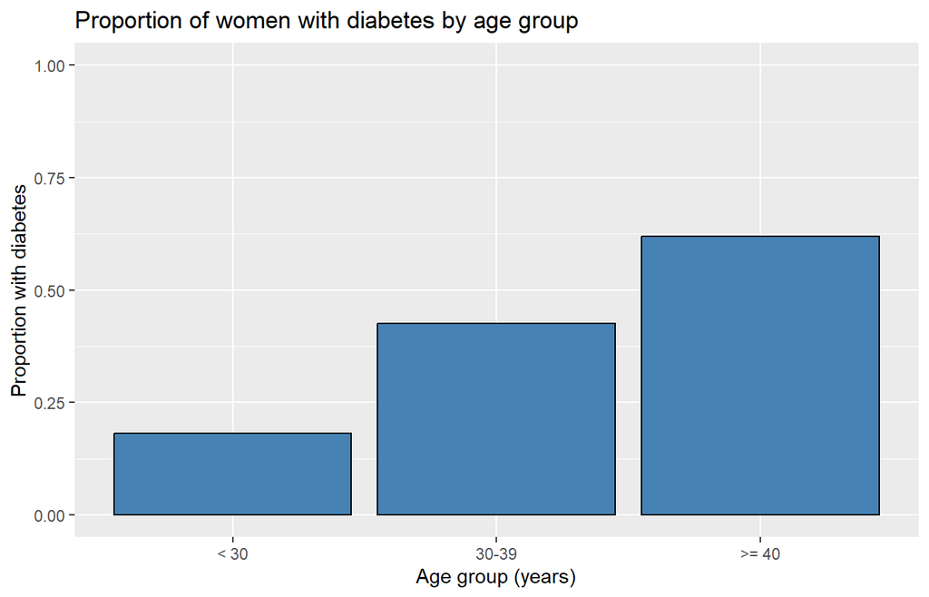

```r
ggplot(diabetes_by_age, aes(x = age_group, y = proportion)) +
  geom_col(fill = "steelblue", colour = "black") +
  ylim(0, 1) +
  labs(title = "Proportion of women with diabetes by age group",
       x = "Age group (years)", y = "Proportion with diabetes")
```

The proportion of women with diabetes rises steadily with age, from about 18% in women under 30 to 42% at 30-39 and 62% from 40 onwards. Diabetes is a chronic disease, so cases accumulate as the population ages.

## 3.3 Women with diabetes and above-average BMI

```r
mean_bmi <- mean(pima$bmi)
mean_bmi
```

```
## [1] 32.31
```

```r
high_bmi_diabetes <- pima %>%
  filter(type == "Yes", bmi > mean_bmi)

table(age_group = high_bmi_diabetes$age_group)
```

```
## age_group
##  < 30 30-39 >= 40
##    14    12    22
```

There are 48 women with diabetes and a BMI above the sample mean (32.3): 14 are under 30, 12 are aged 30-39 and 22 are 40 or older.

## 3.4 High glucose without a diabetes diagnosis

```r
pima %>%
  filter(glu > 140, type == "No") %>%
  nrow()
```

```
## [1] 20
```

Twenty women have a plasma glucose above 140 mg/dl without being diagnosed with diabetes. Clinically, they could be people with **impaired glucose tolerance or prediabetes** at high risk of developing diabetes, or measurements affected by non-fasting conditions. They would be a priority group for follow-up. A large number of such women could also suggest that the diagnostic threshold behaves differently in this population.

## 3.5 Generalising to European women

The model could not be used directly. The sample comes from a specific population with its own genetics, lifestyle and diet, so the relationships learned may not hold in European women. With only 200 women, the estimates are also imprecise. Before using such a model, one should validate it on European data, evaluate its performance by subgroup (age, BMI, family history), and retrain or recalibrate it with a large and representative European sample. The model should support, not replace, clinical judgement.

# Part 4. Descriptive statistics and graphics

## 4.1 Descriptive statistics

```r
continuous_vars <- c("glu", "bp", "bmi", "age")

pima %>%
  select(all_of(continuous_vars)) %>%
  summarise(across(everything(), list(
    mean = mean, sd = sd, median = median,
    q1 = ~ quantile(.x, 0.25), q3 = ~ quantile(.x, 0.75), iqr = IQR
  ))) %>%
  tidyr::pivot_longer(everything(),
                      names_to = c("variable", ".value"),
                      names_pattern = "(.*)_(mean|sd|median|q1|q3|iqr)") %>%
  mutate(across(where(is.numeric), ~ round(.x, 2)))
```

| variable | mean | sd | median | q1 | q3 | iqr |
| --- | --- | --- | --- | --- | --- | --- |
| glu | 123.97 | 31.67 | 120.5 | 100.00 | 144.00 | 44.00 |
| bp | 71.26 | 11.48 | 70.0 | 64.00 | 78.00 | 14.00 |
| bmi | 32.31 | 6.13 | 32.8 | 27.58 | 36.50 | 8.92 |
| age | 32.11 | 10.98 | 28.0 | 23.00 | 39.25 | 16.25 |

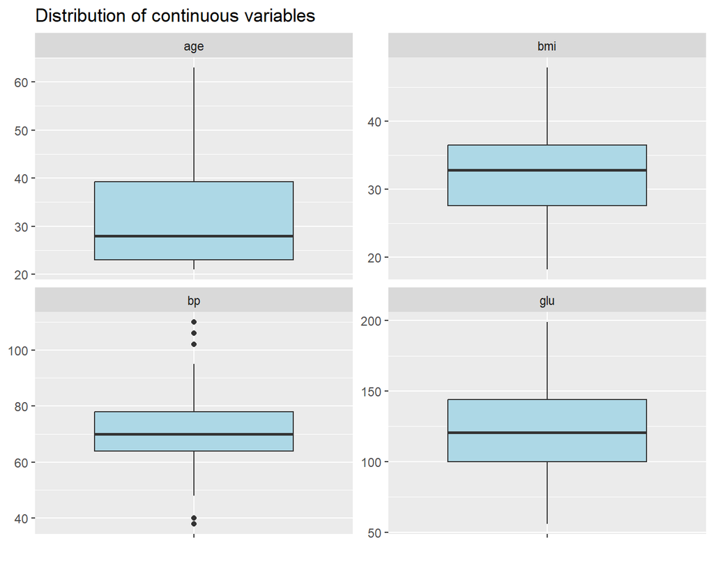

```r
pima %>%
  select(all_of(continuous_vars)) %>%
  tidyr::pivot_longer(everything(), names_to = "variable", values_to = "value") %>%
  ggplot(aes(x = "", y = value)) +
  geom_boxplot(fill = "lightblue") +
  facet_wrap(~ variable, scales = "free_y") +
  labs(title = "Distribution of continuous variables", x = NULL, y = NULL)
```

Age is clearly right-skewed (mean 32.1 versus median 28), because most women are young and a few are much older. Blood pressure has five outliers outside the whiskers. Glucose (mean 124.0, median 120.5) and BMI (mean 32.3, median 32.8) are fairly symmetric with no outliers.

## 4.2 Glucose by diabetes status

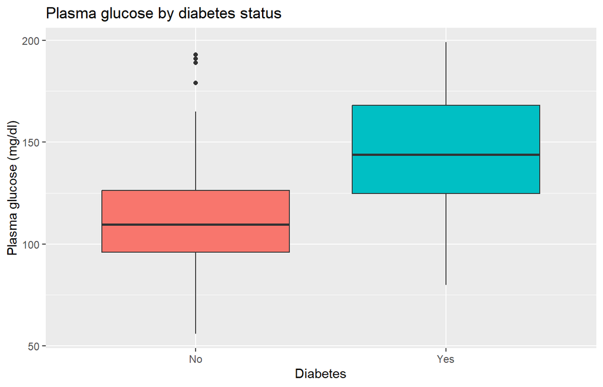

```r
ggplot(pima, aes(x = type, y = glu, fill = type)) +
  geom_boxplot(show.legend = FALSE) +
  labs(title = "Plasma glucose by diabetes status",
       x = "Diabetes", y = "Plasma glucose (mg/dl)")
```

```r
tapply(pima$glu, pima$type, median)
```

```
##    No   Yes
## 109.5 144.0
```

The boxes barely overlap: median glucose is 144.0 mg/dl in women with diabetes versus 109.5 mg/dl in women without, so glucose is clearly higher in diabetes, as expected from the diagnostic definition of the disease.

## 4.3 Age group and diabetes

```r
age_diabetes_counts <- table(age_group = pima$age_group, diabetes = pima$type)
age_diabetes_counts
```

```
##          diabetes
## age_group No Yes
##     < 30  90  20
##     30-39 23  17
##     >= 40 19  31
```

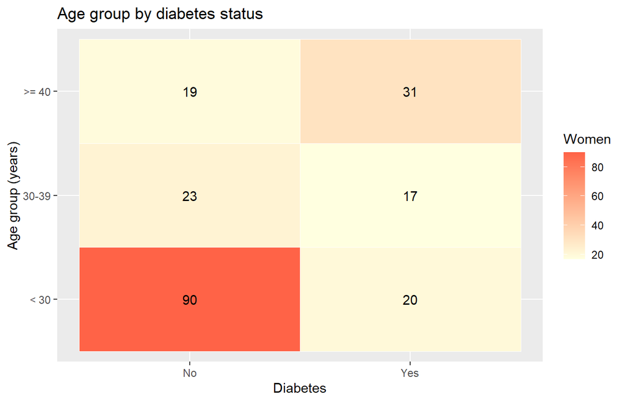

```r
ggplot(as.data.frame(age_diabetes_counts),
       aes(x = diabetes, y = age_group, fill = Freq)) +
  geom_tile(colour = "white") +
  geom_text(aes(label = Freq)) +
  scale_fill_gradient(low = "lightyellow", high = "tomato") +
  labs(title = "Age group by diabetes status",
       x = "Diabetes", y = "Age group (years)", fill = "Women")
```

The most frequent combination is women under 30 without diabetes (90 women, 45% of the sample). Proportionally, however, the pattern reverses with age: diabetes is present in 18% of women under 30, 42% of those aged 30-39 and 62% of those aged 40 or older.

## 4.4 Normality of BMI in women with diabetes

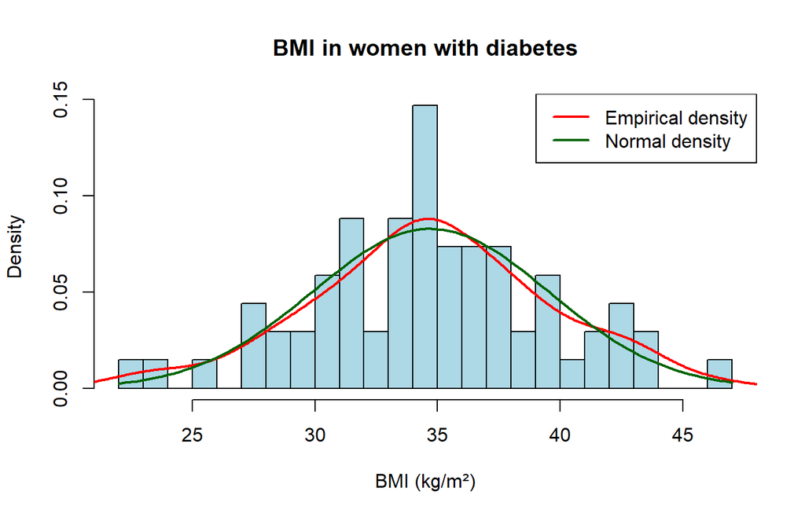

```r
bmi_diabetes <- pima %>%
  filter(type == "Yes") %>%
  pull(bmi)

hist(bmi_diabetes,
     freq = FALSE, breaks = 20, col = "lightblue", border = "black",
     xlab = "BMI (kg/m²)", ylab = "Density",
     main = "BMI in women with diabetes")
lines(density(bmi_diabetes), col = "red", lwd = 2)
curve(dnorm(x, mean = mean(bmi_diabetes), sd = sd(bmi_diabetes)),
      add = TRUE, col = "darkgreen", lwd = 2)
legend("topright", legend = c("Empirical density", "Normal density"),
       col = c("red", "darkgreen"), lwd = 2)
```

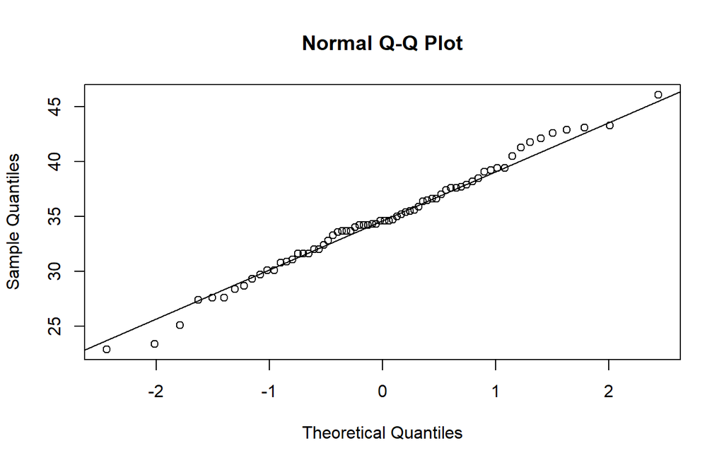

```r
qqnorm(bmi_diabetes)
qqline(bmi_diabetes)
```

```r
# H0: the data come from a normal distribution
shapiro.test(bmi_diabetes)
```

```
##
##  Shapiro-Wilk normality test
##
## data:  bmi_diabetes
## W = 0.9904, p-value = 0.8835
```

The Shapiro-Wilk test gives p = 0.883. Since the null hypothesis is that the data are normal and p is far above 0.05, there is no evidence against normality, so BMI in women with diabetes can be treated as approximately normal. The Q-Q plot agrees: the points follow the reference line, with only small deviations in the tails.

## 4.5 Correlation matrix

```r
numeric_vars <- pima %>%
  select(skin, bmi, ped, age, npreg, glu, bp)

correlation_matrix <- cor(numeric_vars)
round(correlation_matrix, 2)
```

```
##       skin  bmi   ped   age npreg  glu    bp
## skin  1.00 0.66  0.10  0.25  0.11 0.22  0.26
## bmi   0.66 1.00  0.19  0.13  0.06 0.22  0.24
## ped   0.10 0.19  1.00 -0.07 -0.12 0.06 -0.05
## age   0.25 0.13 -0.07  1.00  0.60 0.34  0.39
## npreg 0.11 0.06 -0.12  0.60  1.00 0.17  0.25
## glu   0.22 0.22  0.06  0.34  0.17 1.00  0.27
## bp    0.26 0.24 -0.05  0.39  0.25 0.27  1.00
```

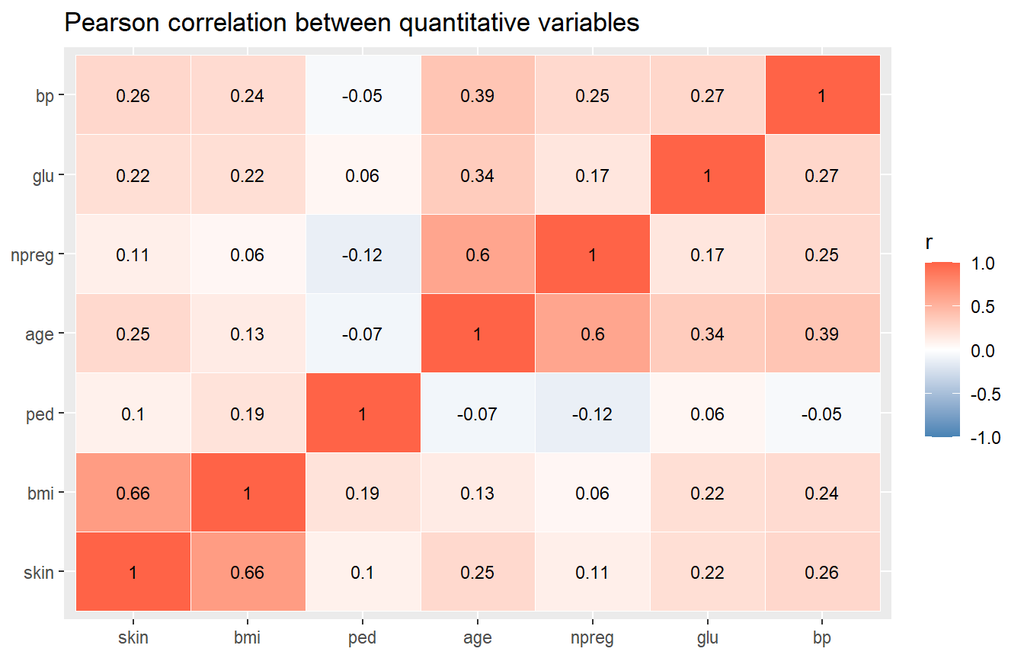

```r
ggplot(as.data.frame(as.table(correlation_matrix)),
       aes(x = Var1, y = Var2, fill = Freq)) +
  geom_tile(colour = "white") +
  geom_text(aes(label = round(Freq, 2)), size = 3) +
  scale_fill_gradient2(low = "steelblue", mid = "white", high = "tomato",
                       midpoint = 0, limits = c(-1, 1)) +
  labs(title = "Pearson correlation between quantitative variables",
       x = NULL, y = NULL, fill = "r")
```

The strongest correlation is between skinfold thickness and BMI (r = 0.66). Both are measures of body adiposity, so it is expected that they increase together. The second strongest is between the number of pregnancies and age (r = 0.60), which is also expected, as older women have had more time to become pregnant. The remaining correlations are weak or moderate. Correlation captures only linear association and does not imply causation.